# Multiple regression

Nic Rivers

9/30/2019

## Commuting to activities, traffic congestion, and quality of life

In this lab, we will use the General Social Survey (2015) to investigate the links between commuting, traffic congesion, and quality of life. First, we will load our required packages and the data:

```r
library(tidyverse)
library(huxtable)

dat <- read_csv("gss-89M0034-E-2015-c-29-main.zip")
```

Let’s start with some visualizations. First, let’s see how subjective well-being (SLM_01) relates to traffic congestion (for people who drive to work). It looks like on average, people who experience more congestion rate the quality of their lives worse.

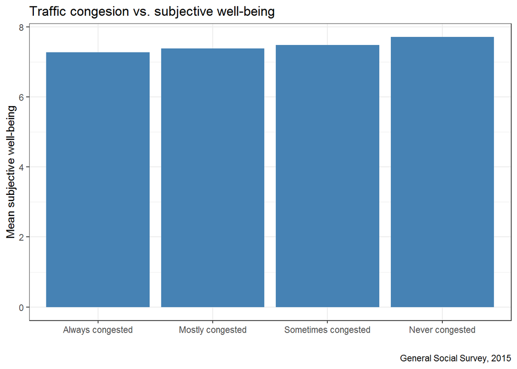

```r
dat %>%
  # Just include people who report congestion
  filter(CTW_190 %in% c(1,2,3,4),
         # Keep valid level of subjective well-being
         SLM_01 %in% 0:10,
         # Keep people who drive to work
         CTW_140A == 1) %>%
  # Relabel
  mutate(CTW_190 = factor(CTW_190, labels=c("Always congested",
                                            "Mostly congested",
                                            "Sometimes congested",
                                            "Never congested"))) %>%
  group_by(CTW_190) %>%
  summarise(swb = mean(SLM_01)) %>%
  # Note how we can "pipe" to a ggplot
  ggplot(aes(x=CTW_190, y=swb)) +
    geom_col(fill="steelblue") +
  theme_bw() +
  labs(title="Traffic congesion vs. subjective well-being",
       caption="General Social Survey, 2015",
       y="Mean subjective well-being",
       x="")
```

Now let’s compare commuting time to subjective well-being, again focusing on drivers.

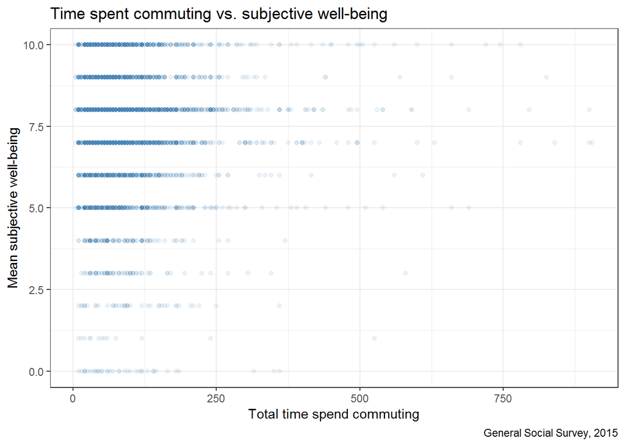

```r
dat %>%
  # Just include people who report congestion
  filter(DUR07 < 9995,
         DUR07 > 0,
         # Keep valid level of subjective well-being
         SLM_01 %in% 0:10,
         # Keep people who drive to work
         CTW_140A == 1) %>%
  # Note how we can "pipe" to a ggplot
  ggplot(aes(x=DUR07, y=SLM_01)) +
    geom_point(colour="steelblue", alpha = 0.1) +
  theme_bw() +
  labs(title="Time spent commuting vs. subjective well-being",
       caption="General Social Survey, 2015",
       y="Mean subjective well-being",
       x="Total time spend commuting")
```

As is typical, direct plots of micro-data are not that revealing. One potential strategy is to group the x-axis into bins, and take the mean subjective well-being in each bin.

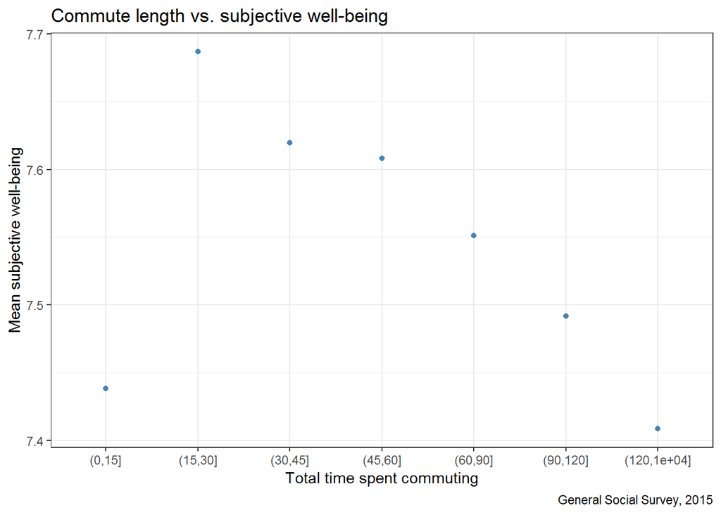

```r
dat %>%
  # Just include people who report congestion
  filter(DUR07 < 9995,
         DUR07 > 0,
         # Keep valid level of subjective well-being
         SLM_01 %in% 0:10,
         # Keep people who drive to work
         CTW_140A == 1) %>%
  # Create "bins" based on the time of commute to work
  mutate(time_bin = cut(DUR07, breaks = c(0,15,30,45,60,90,120,9995))) %>%
  group_by(time_bin) %>%
  summarise(mean_swb = mean(SLM_01)) %>%
  # Note how we can "pipe" to a ggplot
  ggplot(aes(x=time_bin, y=mean_swb)) +
    geom_point(colour="steelblue") +
  theme_bw() +
  labs(title="Commute length vs. subjective well-being",
       caption="General Social Survey, 2015",
       y="Mean subjective well-being",
       x="Total time spent commuting")
```

This points to an interesting pattern. People with *very* short amounts of travel – less than 15 minutes in total per day – have a lower self-reported well being. People with between 15 and 30 minutes of total commuting have substantially higher self-reported well-being. After that point, self-reported well-being appears to drop with additional time spent commuting. This suggestst that the relationship between time spent commuting and subjective well-being may not be linear. We should keep this in mind as wel turn to a (ilnear) regression analysis.

Let’s turn to a regression analysis. First, let’s conduct a simple regression of subjective well-being on commute time.

```r
drivers <- dat %>%
  # Just include people who commute (less than 3 hours)
  filter(DUR07 < 180,
         DUR07 > 0,
         # Keep valid level of subjective well-being
         SLM_01 %in% 0:10,
         # Keep people who drive to work
         CTW_140A == 1) %>%
  mutate(hour_commute = DUR07/60)
# Linear regression
m1 <- lm(SLM_01 ~ hour_commute, data=drivers)
# Report the results
huxreg(m1)
```

|  | (1) |
| --- | --- |
| (Intercept) | 7.685 *** |
|  | (0.049) |
| hour_commute | -0.103 ** |
|  | (0.037) |
| N | 5184 |
| R2 | 0.001 |
| logLik | -10222.567 |
| AIC | 20451.133 |
| *** p < 0.001; ** p < 0.01; * p < 0.05. |  |

We can try controlling for other variables that potentially confound this relationship. What other variables should we include? To start, let’s include income, and some demographic characteristics in our model. Then we also include geographic variables. Do these models reveal the causal effect of commuting on income?

```r
m2 <- lm(SLM_01 ~ hour_commute + factor(AGEGR10) + factor(SEX) + factor(MARSTAT) + factor(CXRFLAG) + factor(HHINCG1), data=drivers)
m3 <- lm(SLM_01 ~ hour_commute + factor(AGEGR10) + factor(SEX) + factor(MARSTAT) + factor(CXRFLAG) + factor(HHINCG1) + factor(LUC_RST) + factor(PRV), data=drivers)
# Report the results
huxreg(m1,m2,m3)
```

|  | (1) | (2) | (3) |
| --- | --- | --- | --- |
| (Intercept) | 7.685 *** | 8.055 *** | 8.171 *** |
|  | (0.049) | (0.189) | (0.216) |
| hour_commute | -0.103 ** | -0.117 ** | -0.102 ** |
|  | (0.037) | (0.037) | (0.037) |
| factor(AGEGR10)2 |  | -0.178 | -0.156 |
|  |  | (0.109) | (0.109) |
| factor(AGEGR10)3 |  | -0.335 ** | -0.315 ** |
|  |  | (0.111) | (0.111) |
| factor(AGEGR10)4 |  | -0.438 *** | -0.430 *** |
|  |  | (0.110) | (0.110) |
| factor(AGEGR10)5 |  | -0.318 ** | -0.319 ** |
|  |  | (0.113) | (0.113) |
| factor(AGEGR10)6 |  | 0.060 | 0.059 |
|  |  | (0.153) | (0.153) |
| factor(AGEGR10)7 |  | 0.524 | 0.573 |
|  |  | (0.370) | (0.370) |
| factor(SEX)2 |  | 0.126 ** | 0.123 * |
|  |  | (0.048) | (0.048) |
| factor(MARSTAT)2 |  | -0.158 * | -0.202 ** |
|  |  | (0.074) | (0.076) |
| factor(MARSTAT)3 |  | -0.331 * | -0.321 * |
|  |  | (0.162) | (0.161) |
| factor(MARSTAT)4 |  | -0.636 *** | -0.623 *** |
|  |  | (0.135) | (0.134) |
| factor(MARSTAT)5 |  | -0.680 *** | -0.664 *** |
|  |  | (0.104) | (0.104) |
| factor(MARSTAT)6 |  | -0.645 *** | -0.647 *** |
|  |  | (0.074) | (0.074) |
| factor(CXRFLAG)2 |  | 0.099 | 0.114 * |
|  |  | (0.058) | (0.058) |
| factor(HHINCG1)2 |  | -0.074 | -0.103 |
|  |  | (0.161) | (0.161) |
| factor(HHINCG1)3 |  | -0.153 | -0.160 |
|  |  | (0.154) | (0.154) |
| factor(HHINCG1)4 |  | -0.002 | -0.016 |
|  |  | (0.154) | (0.154) |
| factor(HHINCG1)5 |  | 0.097 | 0.095 |
|  |  | (0.156) | (0.155) |
| factor(HHINCG1)6 |  | 0.159 | 0.173 |
|  |  | (0.159) | (0.158) |
| factor(HHINCG1)7 |  | 0.147 | 0.150 |
|  |  | (0.163) | (0.163) |
| factor(HHINCG1)8 |  | 0.165 | 0.186 |
|  |  | (0.151) | (0.151) |
| factor(LUC_RST)2 |  |  | 0.165 ** |
|  |  |  | (0.064) |
| factor(LUC_RST)3 |  |  | -0.125 |
|  |  |  | (0.173) |
| factor(PRV)12 |  |  | -0.196 |
|  |  |  | (0.145) |
| factor(PRV)13 |  |  | 0.079 |
|  |  |  | (0.142) |
| factor(PRV)24 |  |  | -0.082 |
|  |  |  | (0.118) |
| factor(PRV)35 |  |  | -0.266 * |
|  |  |  | (0.114) |
| factor(PRV)46 |  |  | -0.100 |
|  |  |  | (0.143) |
| factor(PRV)47 |  |  | -0.257 |
|  |  |  | (0.143) |
| factor(PRV)48 |  |  | -0.223 |
|  |  |  | (0.129) |
| factor(PRV)59 |  |  | -0.312 * |
|  |  |  | (0.127) |
| N | 5184 | 5184 | 5184 |
| R2 | 0.001 | 0.041 | 0.047 |
| logLik | -10222.567 | -10117.518 | -10101.243 |
| AIC | 20451.133 | 20281.036 | 20268.486 |
| *** p < 0.001; ** p < 0.01; * p < 0.05. |  |  |  |

Now, we can try a regression with a different functional form. Let’s try a regression with a log form, and a regression in which we include squared commuting time.

```r
m5 <- lm(SLM_01 ~ log(hour_commute), data=drivers)
m6 <- lm(SLM_01 ~ hour_commute + I(hour_commute^2), data=drivers)
# Report the results
huxreg(m1,m5,m6)
```

|  | (1) | (2) | (3) |
| --- | --- | --- | --- |
| (Intercept) | 7.685 *** | 7.562 *** | 7.675 *** |
|  | (0.049) | (0.024) | (0.085) |
| hour_commute | -0.103 ** |  | -0.084 |
|  | (0.037) |  | (0.143) |
| log(hour_commute) |  | -0.089 * |  |
|  |  | (0.037) |  |
| I(hour_commute^2) |  |  | -0.007 |
|  |  |  | (0.051) |
| N | 5184 | 5184 | 5184 |
| R2 | 0.001 | 0.001 | 0.001 |
| logLik | -10222.567 | -10223.500 | -10222.557 |
| AIC | 20451.133 | 20453.000 | 20453.114 |
| *** p < 0.001; ** p < 0.01; * p < 0.05. |  |  |  |

The second colum uses a log x variable. Now we can interpret somewhat differently. A one-unit increase in x (when x is in logs) is equivalent (approximately) to a 100% increase. So column 2 is saying that a one unit increase in x (100% increase in x) leads to a 0.089 point reduction in SLM. In contrast, in column 1, a one unit increase in x was a one hour increase in x, and that led to a 0.103 reduction in SLM. In column 3, we tried including a commute time squared, but this didn’t lead to a precise model (big standard errors). Nevertheless, we can see what each of these three models predict, and how they differ, using the predict function (like the geom_smooth function).

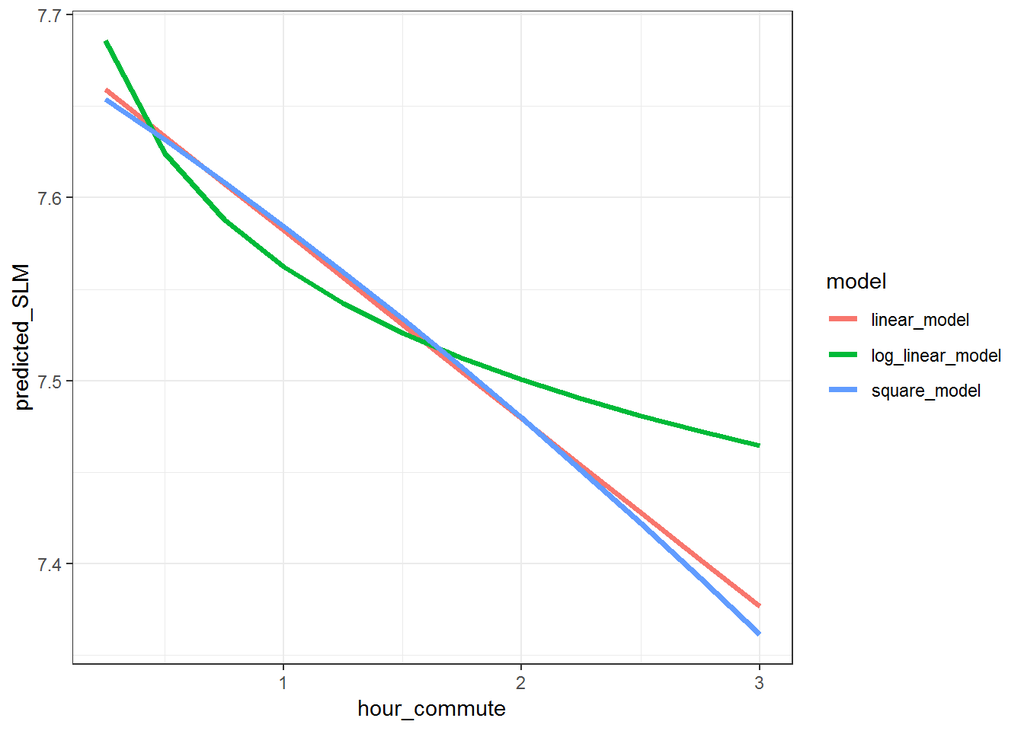

```r
newdat <- tibble(hour_commute = seq(0,3,by=0.25)) %>%
  filter(hour_commute > 0)
newdat$linear_model <- predict(m1, newdat)
newdat$log_linear_model <- predict(m5, newdat)
newdat$square_model <- predict(m6, newdat)
newdat <- newdat %>%
  gather(key=model, value=predicted_SLM, -hour_commute)

ggplot(newdat, aes(x=hour_commute, y=predicted_SLM, colour=model)) +
  geom_line(size=1.25) +
  theme_bw()
```

Finally, let’s try a regression with a discrete dependent variable. To do this, let’s define a variable `very_happy` and set it equal to 1 for someone with a self-reported well-being of 9 or 10. Then let’s estimate a *linear probability model* with this variable as the dependent variable.

```r
drivers <- drivers %>%
  mutate(very_happy = as.numeric(SLM_01 %in% c(9,10)))
m7 <- lm(very_happy ~ hour_commute, data=drivers)
huxreg(m7)
```

|  | (1) |
| --- | --- |
| (Intercept) | 0.310 *** |
|  | (0.012) |
| hour_commute | -0.038 *** |
|  | (0.009) |
| N | 5184 |
| R2 | 0.003 |
| logLik | -3115.840 |
| AIC | 6237.681 |
| *** p < 0.001; ** p < 0.01; * p < 0.05. |  |

How should we interpret this? Here, because the dependent variable is a dummy variable (0/1), we are estimating the impact of a one-unit increase in x on the *probability* of y being true (or 1). Since x is measured in hours, a one hour commute is associated with a reduction in the probability that someone reports being very happy by 3.8%. And the intercept is 31%, which is the mean probability that someone is very happy if they have a 0 hour commute.

Of course, we always need to think about how to interpret cause and effect (4 hurdles) in addition to the statistical analysis.